# Настройка VPN

Лабораторная работа №16

Гафоров Нурмухаммад

Российский университет дружбы народов, Москва, Россия

23.05.2026

# Цель работы

## Цель

Получение навыков настройки VPN-туннеля  
через незащищённое Интернет-соединение.

# Ход выполнения

## Общая топология проекта

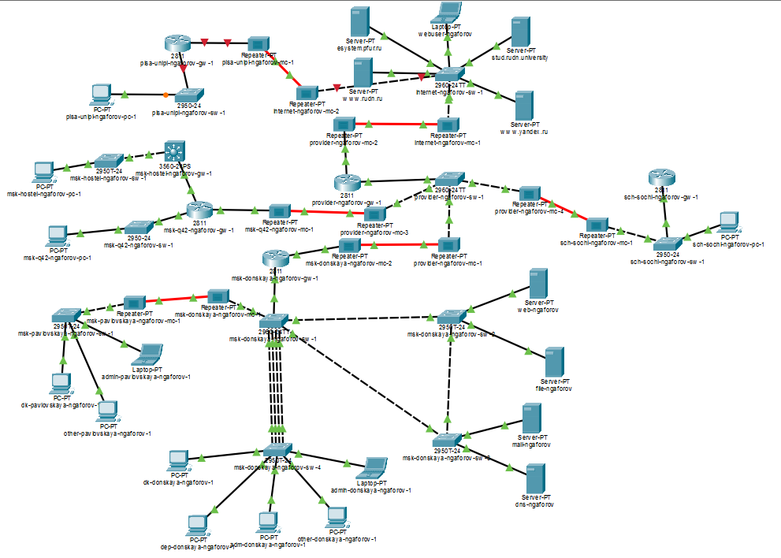

Общая логическая топология проекта

## Физическая область проекта

- Создан город **Pisa**
- Добавлено здание **University of Pisa**
- Оборудование перенесено в соответствующую физическую область
- На карте отображены удалённые площадки и линии связи

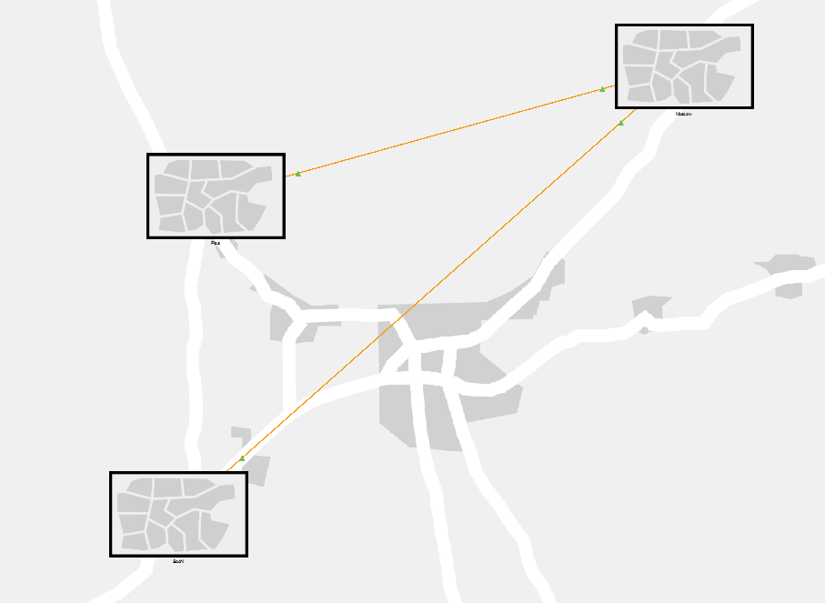

Физическая рабочая область проекта

## Размещение оборудования в стойке

- Проверено расположение устройств в здании Университета г. Пиза
- В стойке размещены маршрутизатор, коммутатор и устройство связи
- Соединения соответствуют логической топологии

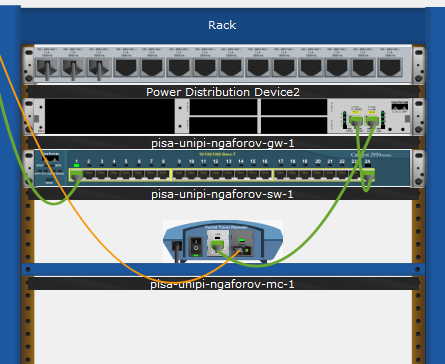

Размещение оборудования в стойке

## Первоначальная настройка маршрутизатора

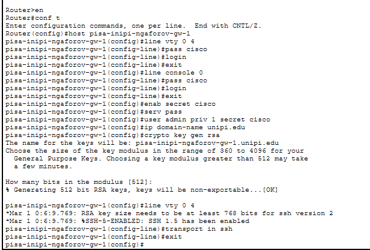

Первоначальная настройка маршрутизатора

## Первоначальная настройка коммутатора

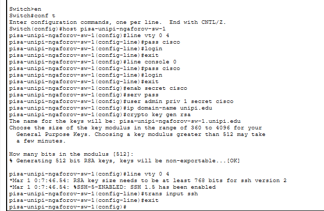

Первоначальная настройка коммутатора

## Настройка интерфейсов маршрутизатора

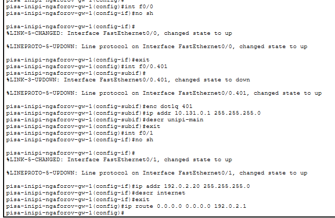

Настройка интерфейсов маршрутизатора

## Настройка VLAN на коммутаторе

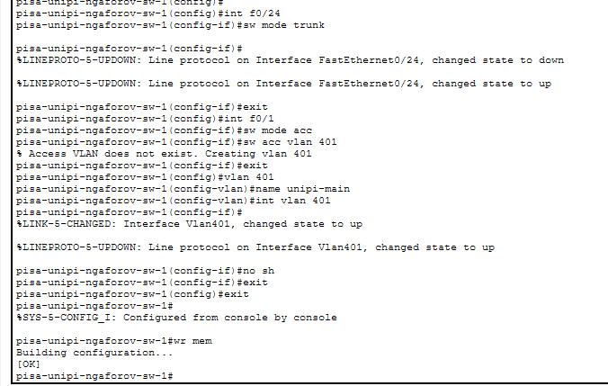

Настройка VLAN 401 и trunk-порта

## Настройка рабочей станции

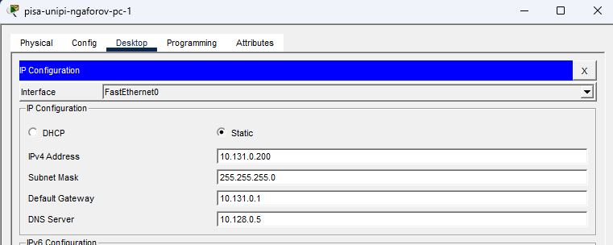

Настройка IP-адреса рабочей станции

# Настройка VPN

## GRE-туннель на стороне «Донская»

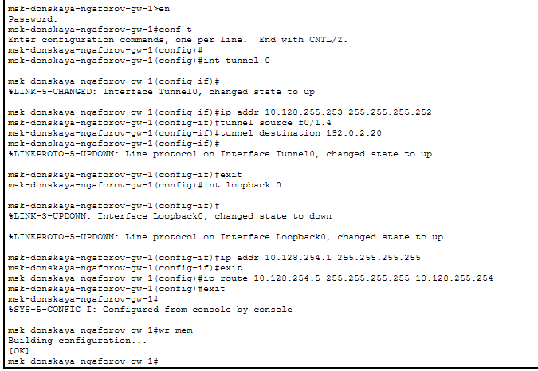

Настройка GRE-туннеля на маршрутизаторе «Донская»

## GRE-туннель на стороне Пизы

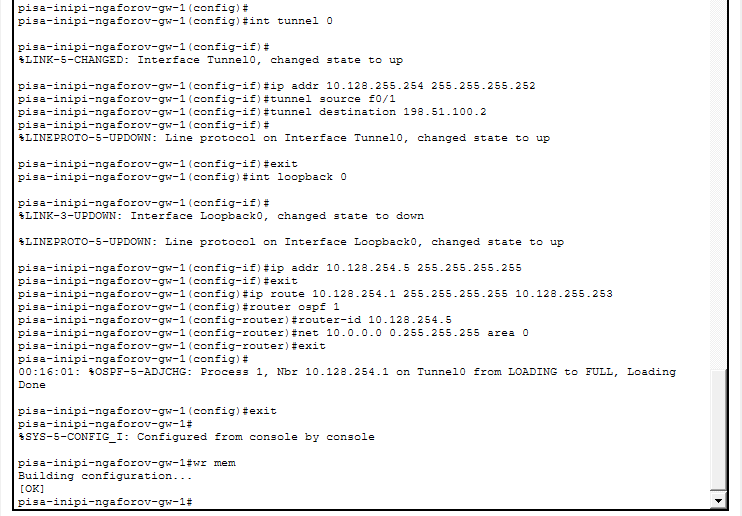

Настройка GRE-туннеля на маршрутизаторе Университета г. Пиза

# Проверка работы

## Проверка доступности узла

- адрес назначения — **10.131.0.200**
- команда **ping** получила 3 ответа из 4
- первый пакет был потерян
- последующие ответы подтвердили доступность узла

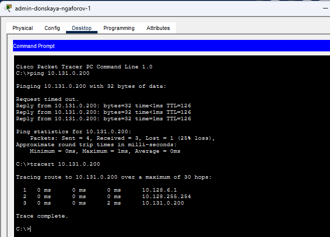

Проверка доступности узла 10.131.0.200

## Трассировка маршрута

- **10.128.6.1** — шлюз сети «Донская»
- **10.128.255.254** — сторона GRE-туннеля в Пизе
- **10.131.0.200** — конечный узел Университета г. Пиза

## Таблица маршрутизации «Донская»

- **10.131.0.0/24**
- получен через **OSPF**
- следующий переход — **10.128.255.254**
- интерфейс выхода — **Tunnel0**

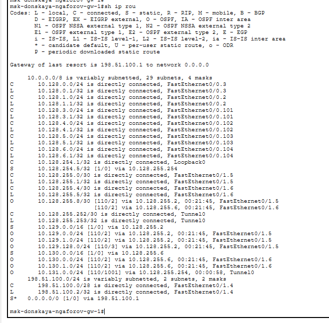

Таблица маршрутизации маршрутизатора «Донская»

## Таблица маршрутизации Университета г. Пиза

- сеть **10.131.0.0/24** подключена напрямую
- адрес шлюза **10.131.0.1** находится на **FastEthernet0/0.401**
- удалённые сети получены через **OSPF**
- маршрут по умолчанию направлен через **192.0.2.1**

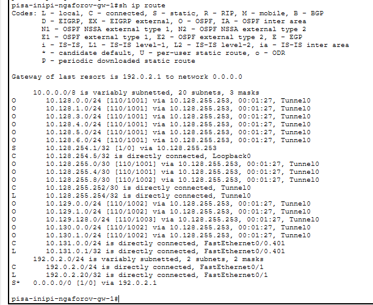

Таблица маршрутизации маршрутизатора Университета г. Пиза

# Итог

## Вывод

В ходе работы:

- создана сеть Университета г. Пиза
- выполнена базовая настройка маршрутизатора и коммутатора
- настроена VLAN **401**
- назначена статическая адресация рабочей станции
- создан GRE-туннель между удалёнными сетями
- настроен обмен маршрутами через OSPF
- проверена доступность узла **10.131.0.200** из сети «Донская»